# Red Wine Quality Exploration by Tao Zhou

I want to see the distribution of volatile acidity. To do this, I created a new feature called “qualFact”, by turning quality into ordered factor type.

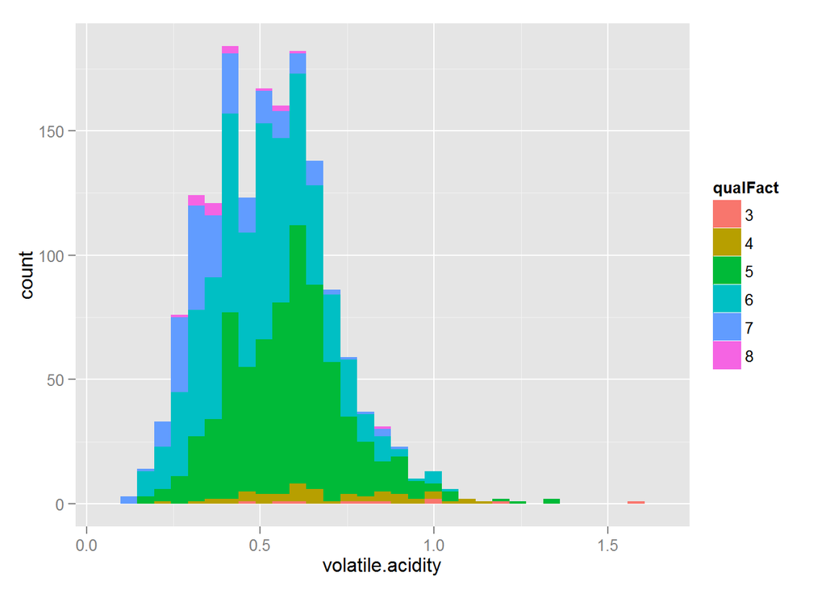

If I draw the boxplot, I get:

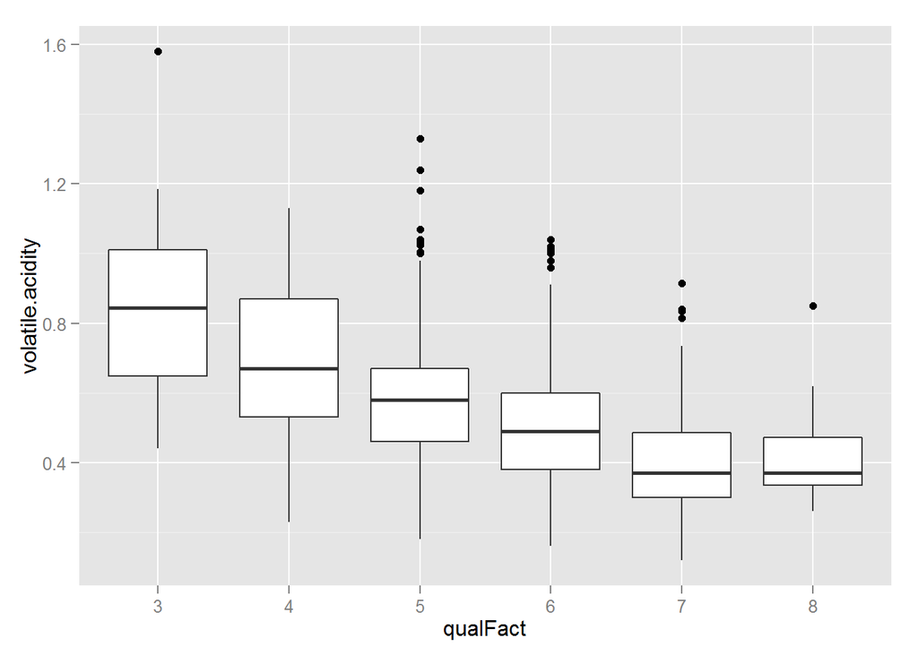

It shows pretty clearly that when volatile acidity decreases, quality increases. This inspires me to use boxplot to explore the correlation between other features and quality.

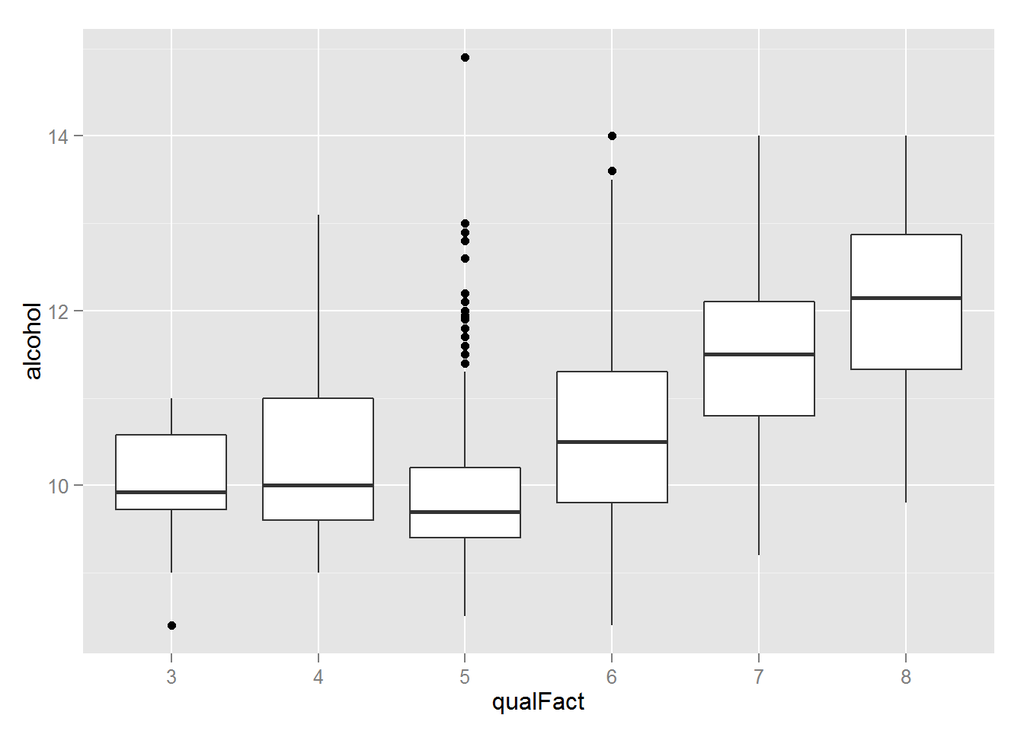

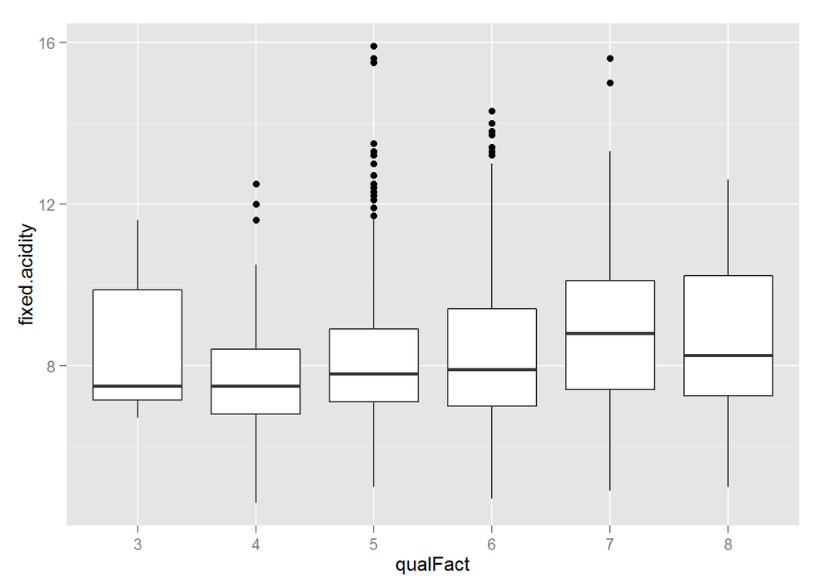

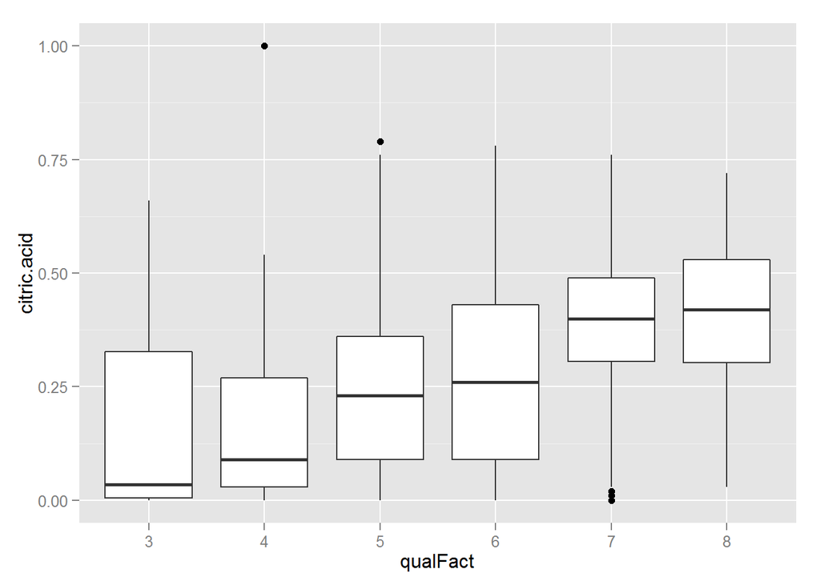

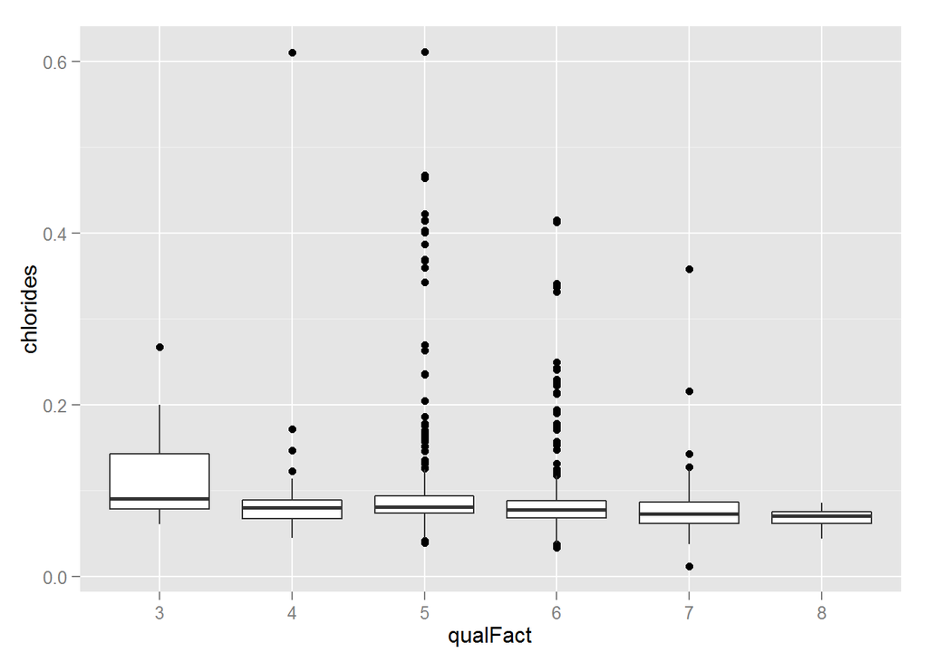

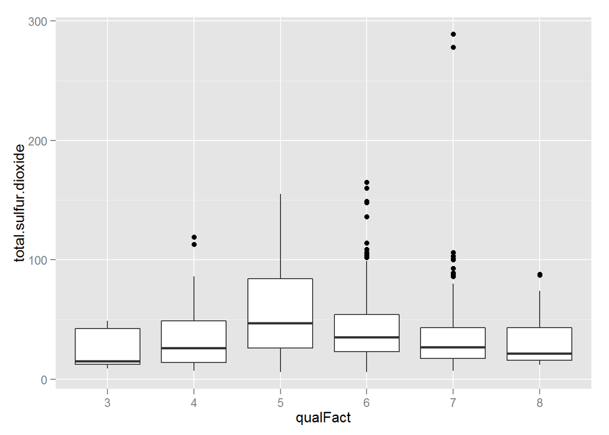

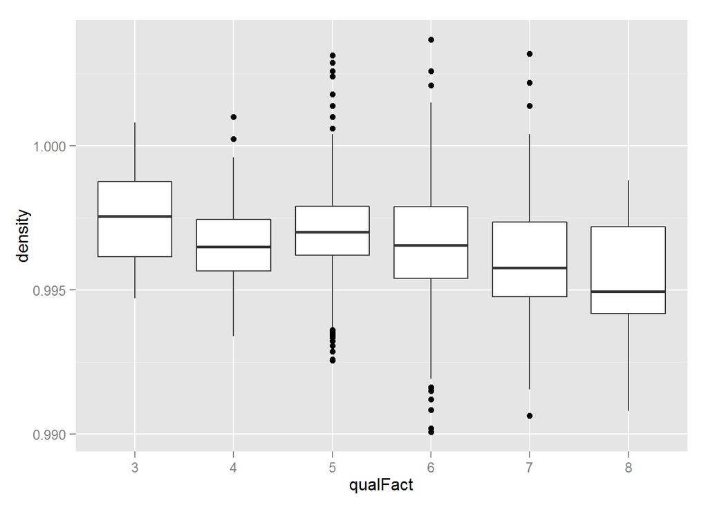

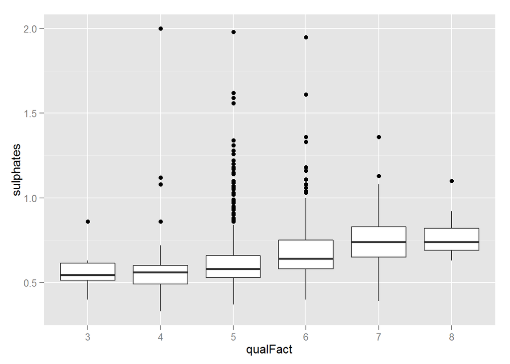

Now it’s easier to see the correlation between alcohol and quality, citric acid and quality, density and quality, and sulphates and quality. I notice that boxplot has an advantage. It can reduce noises from outsiders and show more clear relationship between two variables.

There is strong correlation between pH and fixed acidity. I would like to draw a scatter plot to show that.

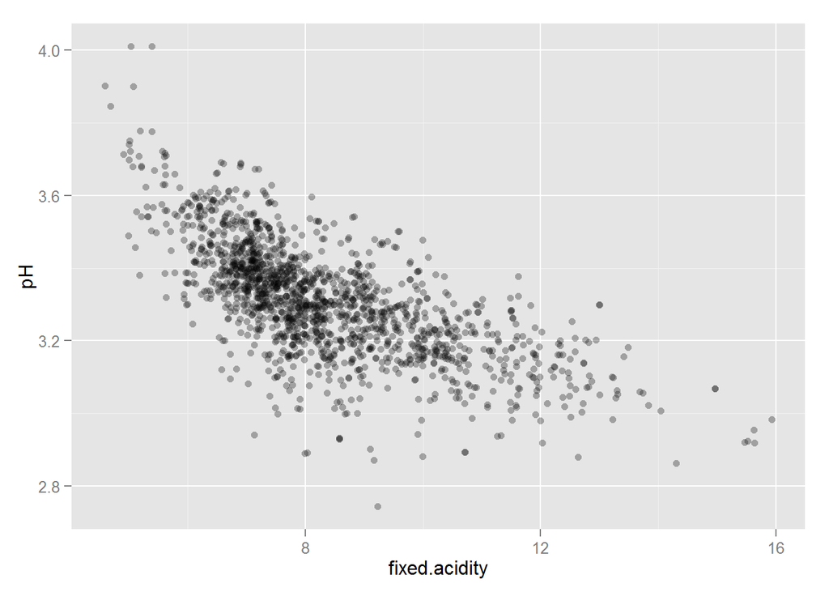

When fixed acidity increases, pH decreases.

And there is strong correlation between fixed acidity and density.

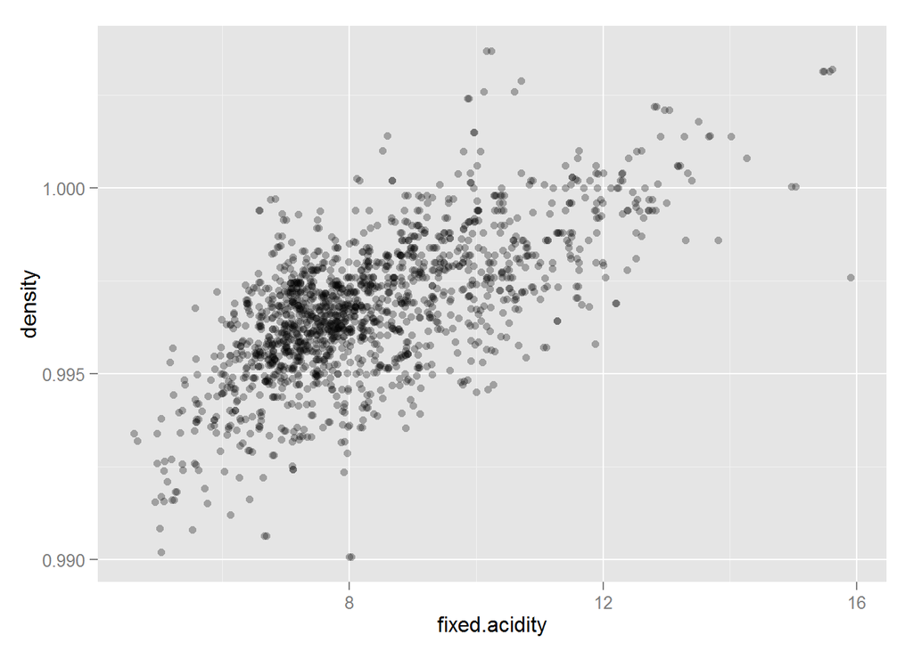

This is interesting. As I mentioned before, my guess is that components producing fixed acidity in red wine tend to have higher density than other components in red wine.

# Bivariate Analysis

### Did you observe any interesting relationships between the other features (not the main feature(s) of interest)?

Yes. I explored the correlation between fixed acidity and pH. They have strong negative correlation. I also explored the correlation between fixed acidity and density. Red wine with higher fixed acidity tends to have higher density.

### What was the strongest relationship you found?

From the calculation of correlation, the strongest correlation is between fixed acidity and pH.

# Multivariate Plots Section

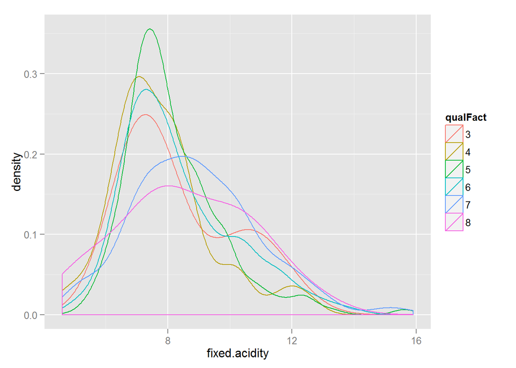

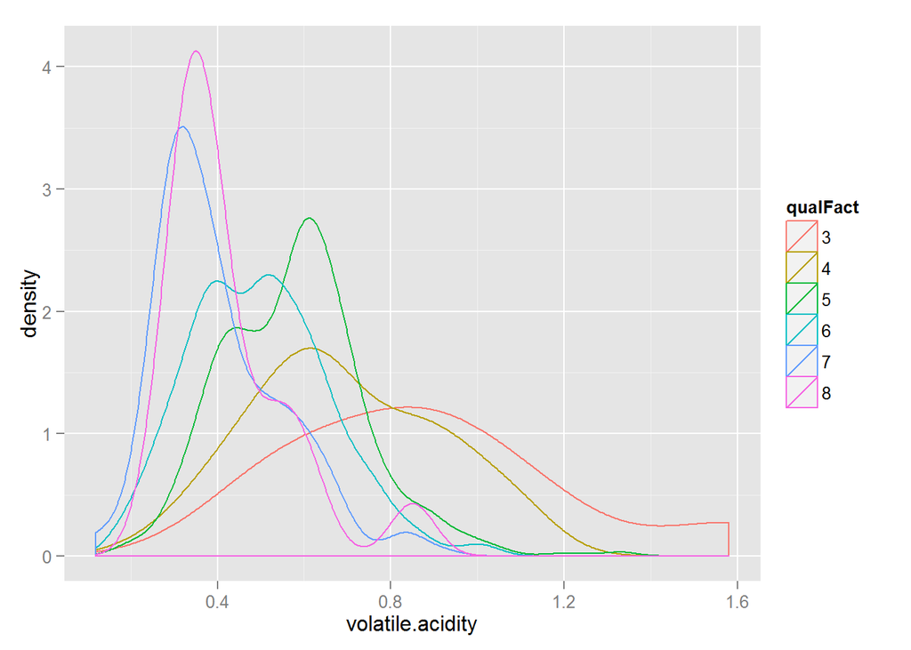

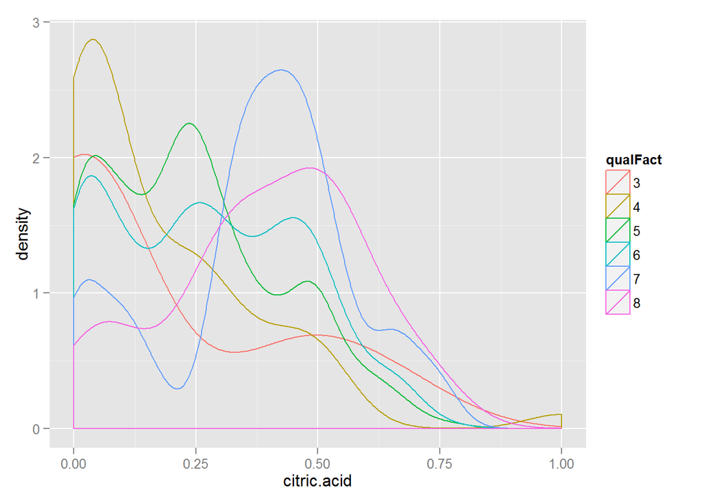

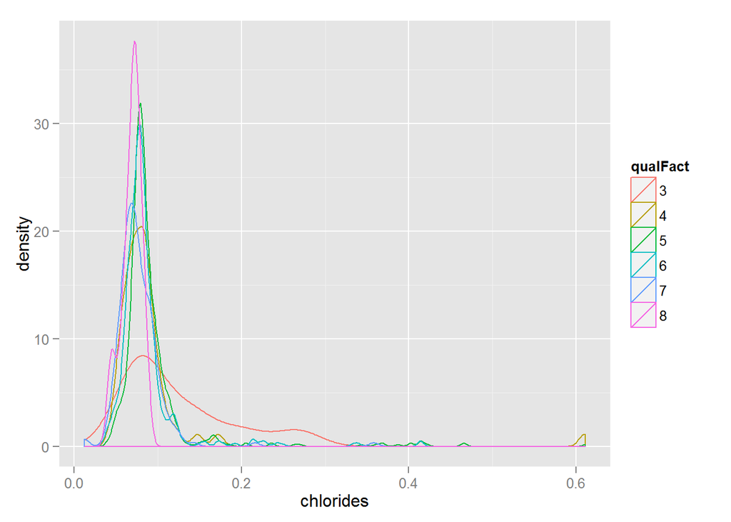

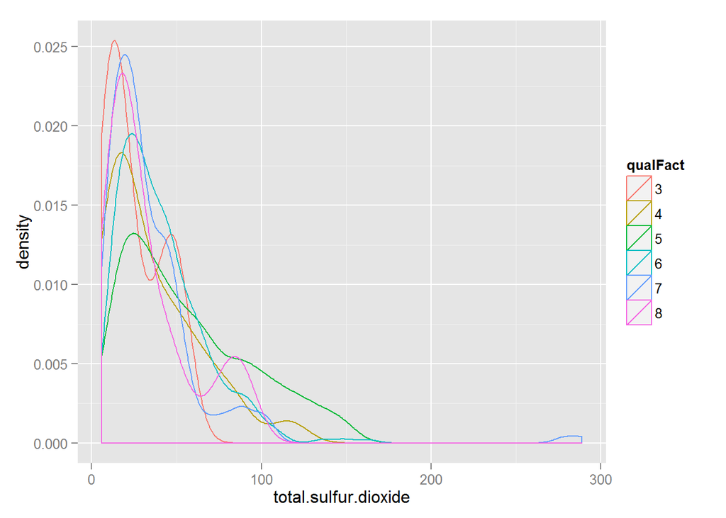

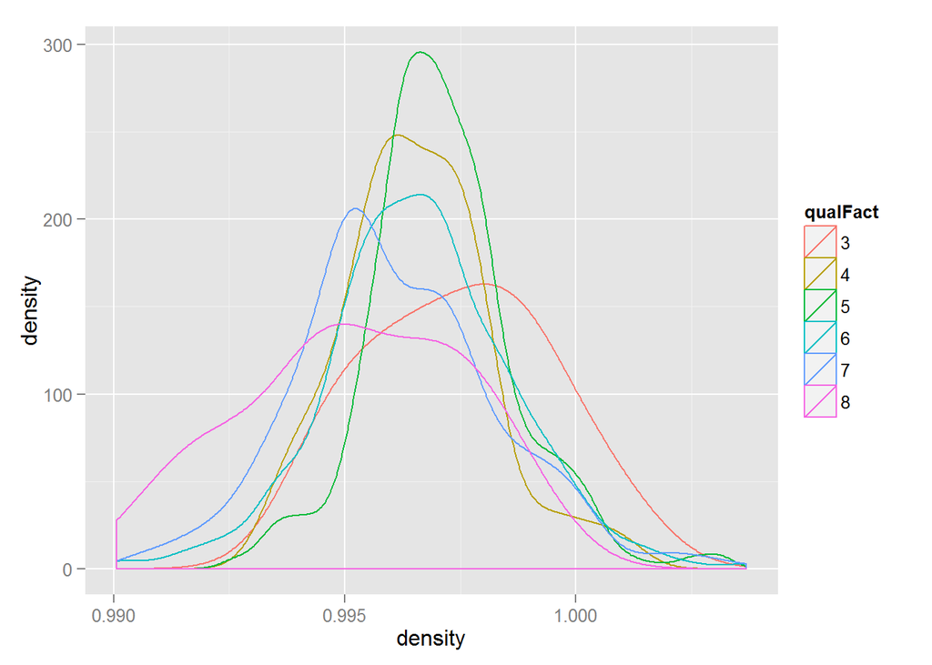

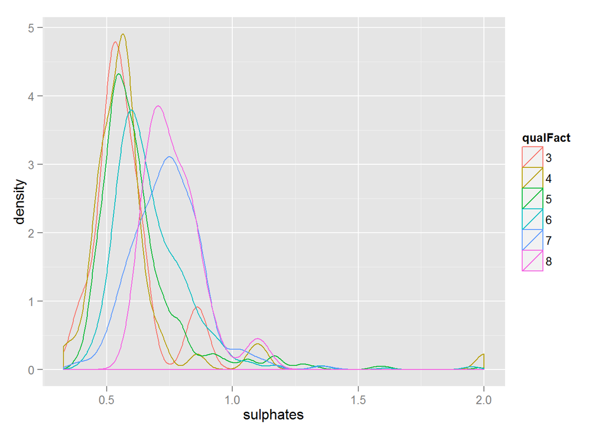

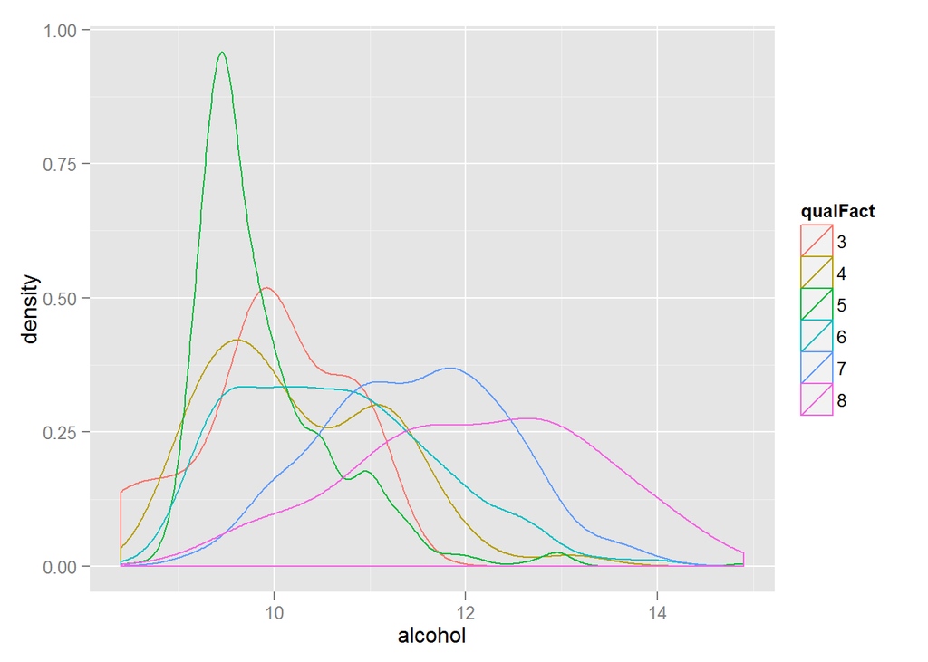

These density plots are telling the same story as the boxplots above.

From the bivariate analysis above, I know that alcohol and volatile acidity are the two most important features affecting quality. I want to draw a scattering plot of alcohol and quality, with points colored according to volatile acidity. To make the trend more clear, I’m going to continously use “geom_jitter”.

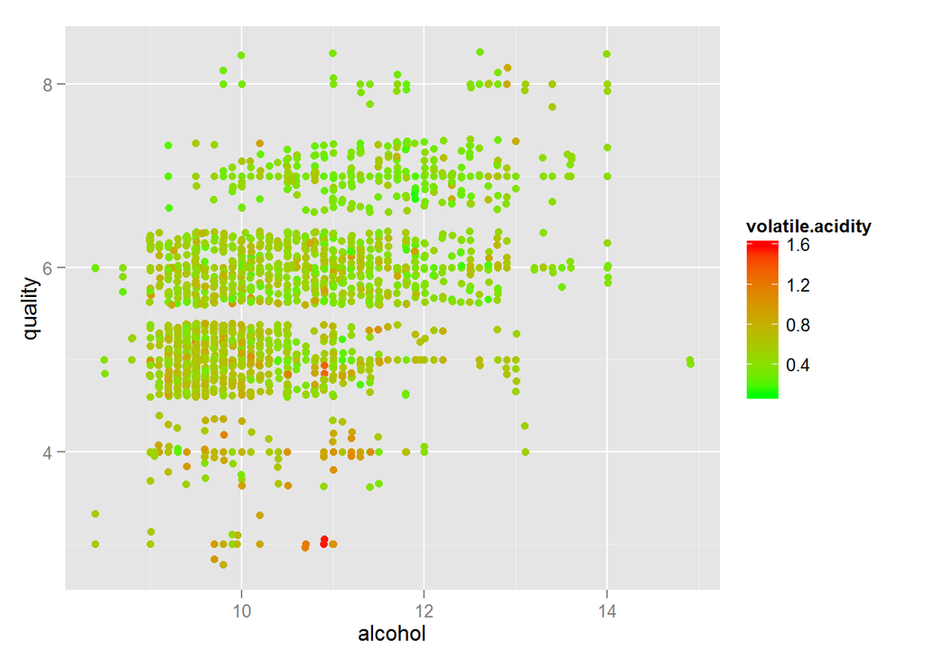

It’s pretty clear that wine quality goes higher with lower volatile acidity when holding alcohol constant.

Let’s explore some other scatter plots, continuously using alcohol to be points’ x axis, quality the y axis and other features the color.

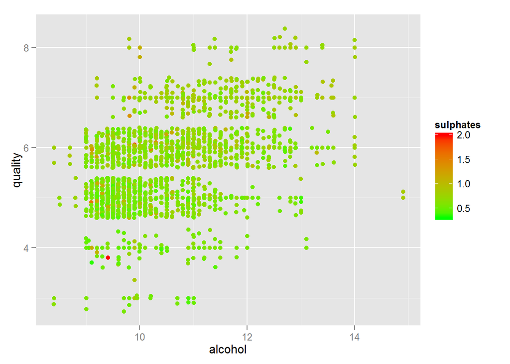

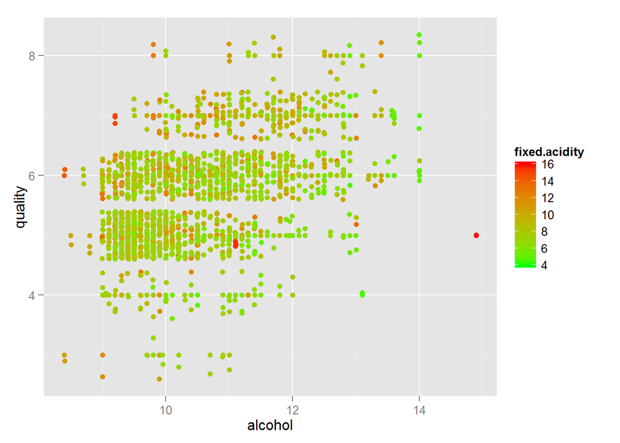

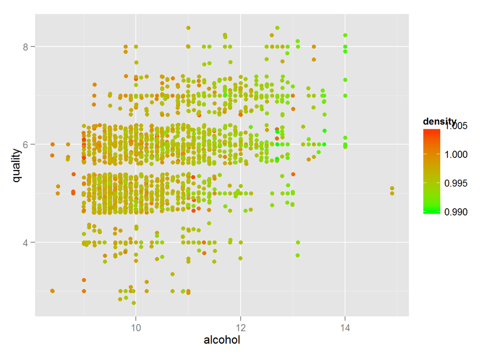

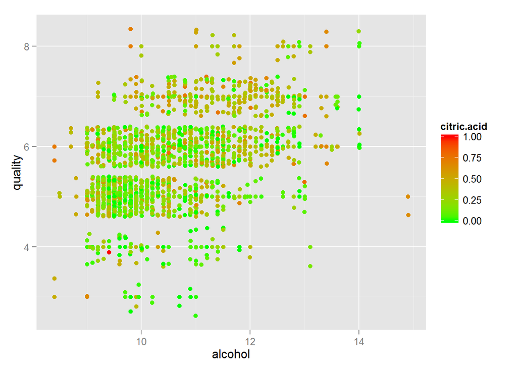

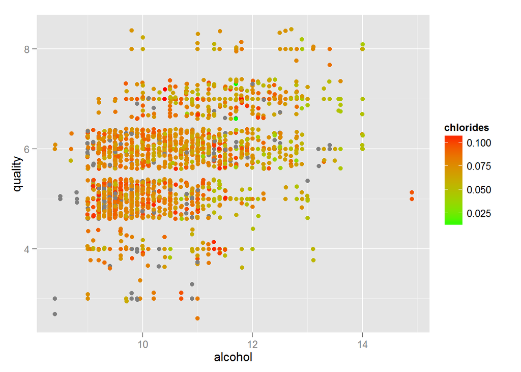

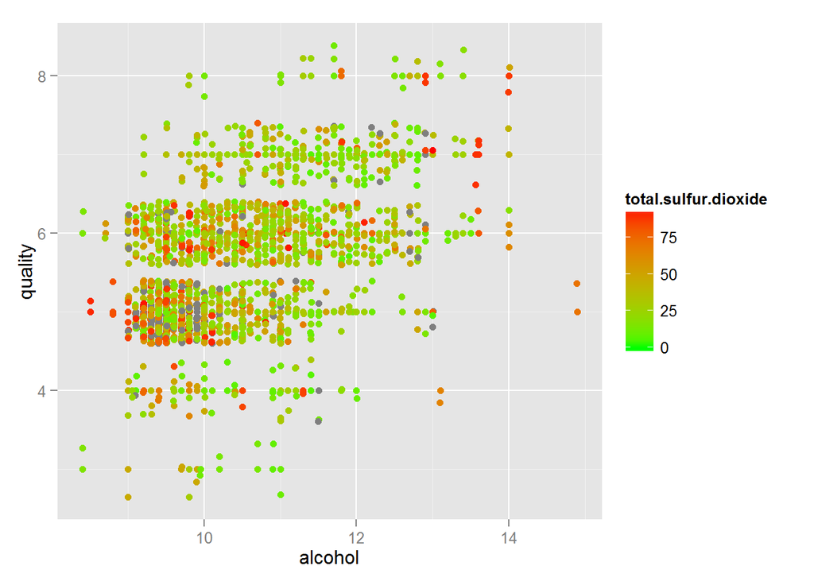

I set the color for chlorides and total sulfur dixoide to be from the minimum to the 90% quantile point because they have very high outsiders. This can been seen from their long tail distributions.

From the quality vs alcohol and citric acid plot, it shows pretty clearly that higher ciric wine tends to have higher quality when alcohol is holding constant. The plot of quality VS alchohol and density may be telling us something but not very clearly. It may be more clear if I divide the points into high density and low density groups.

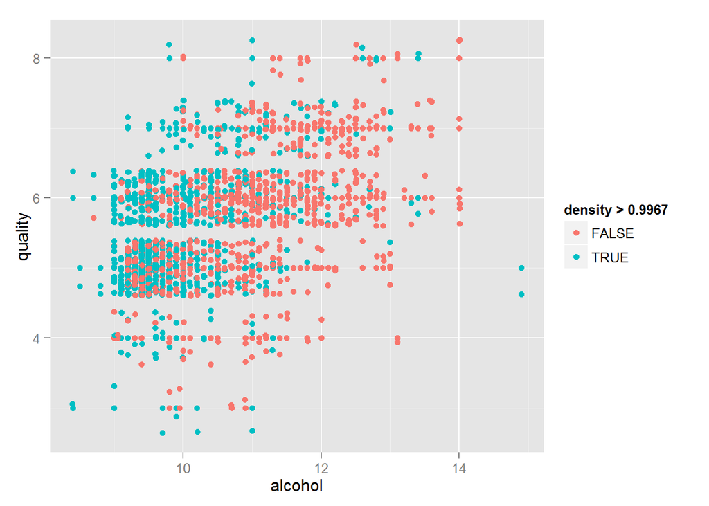

It’s now more clear that lower density wine tends to have higher quality when holding alcohol constant.

As I mentioned above, density seems to be connected to fixed acidity and alcohol. I would like to see the scatter plot of density VS fixed acidity and alcohol.

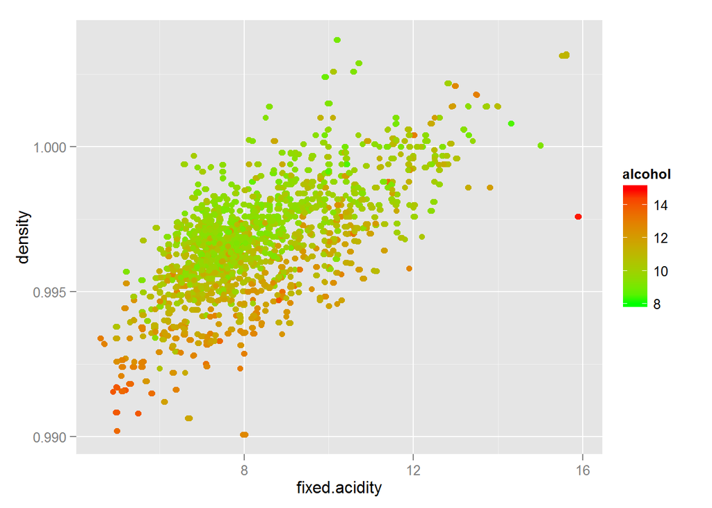

Yes, it’s obvious that there is negative corrleation between alcohol and density, positive correlation between fixed acidity and density.

Now, let’s see the scatter plots if the x axis is volatile acidity and the color of points is the other features.

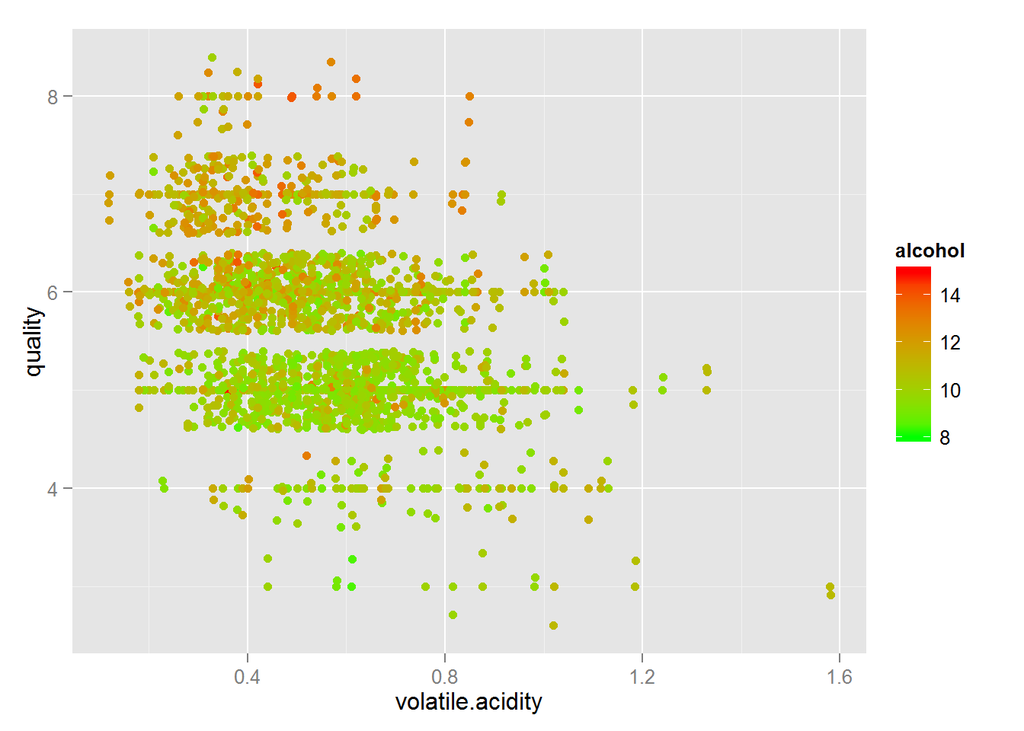

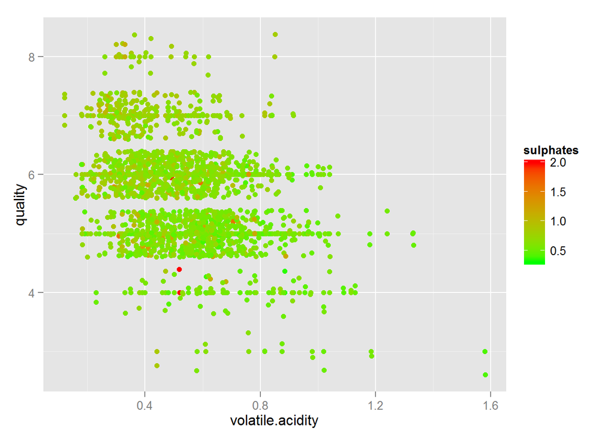

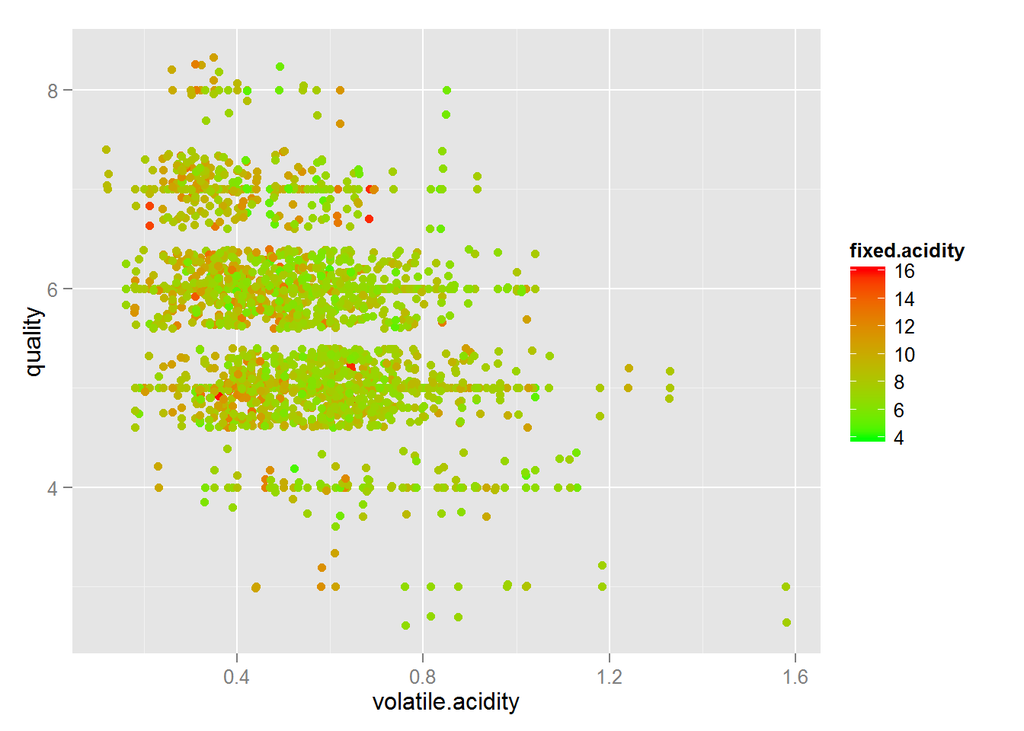

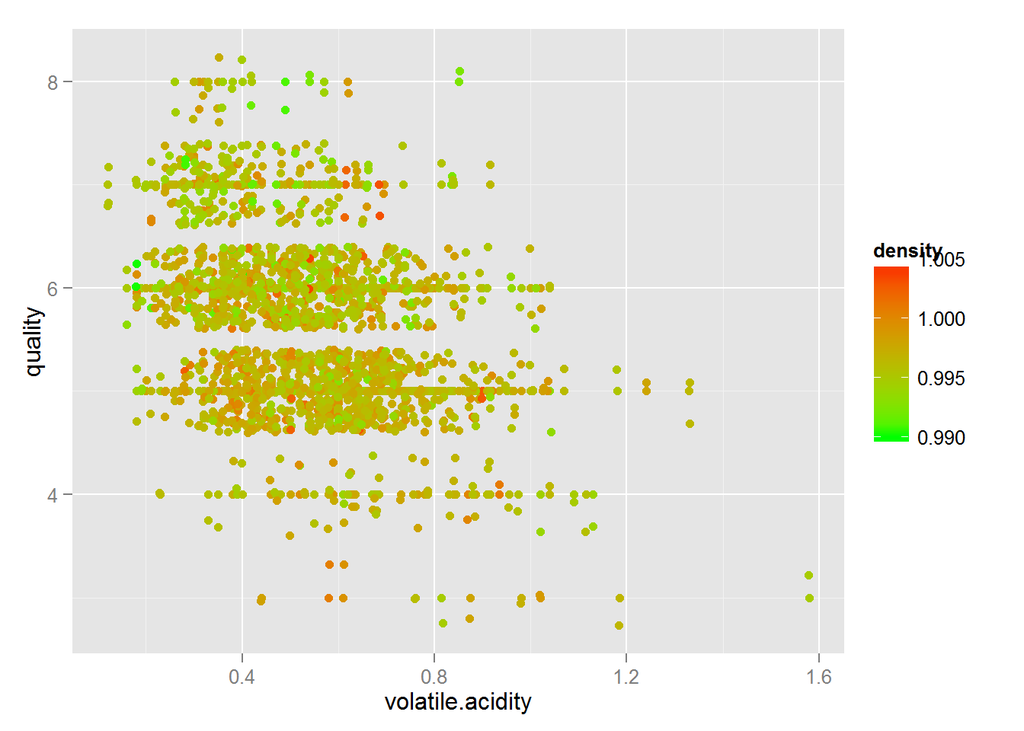

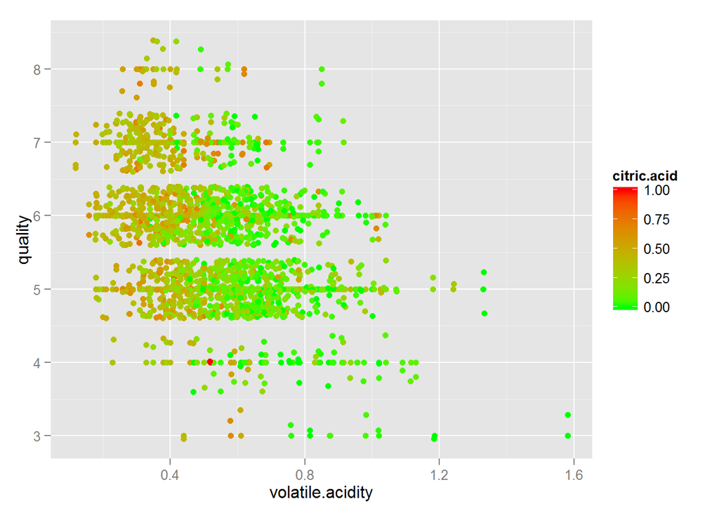

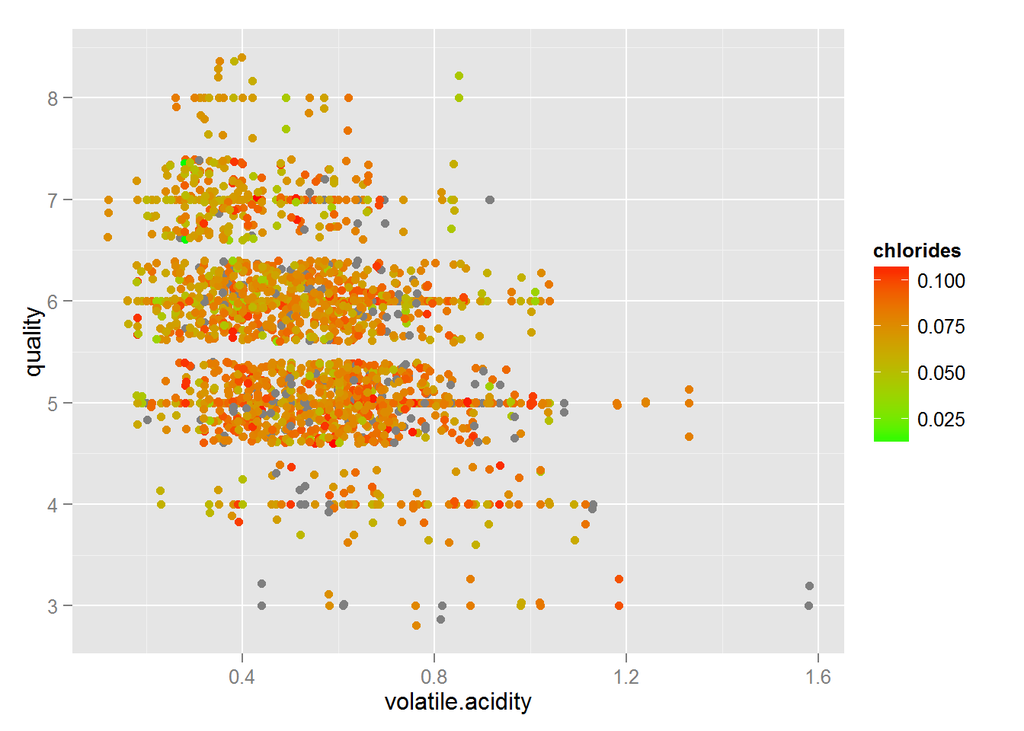

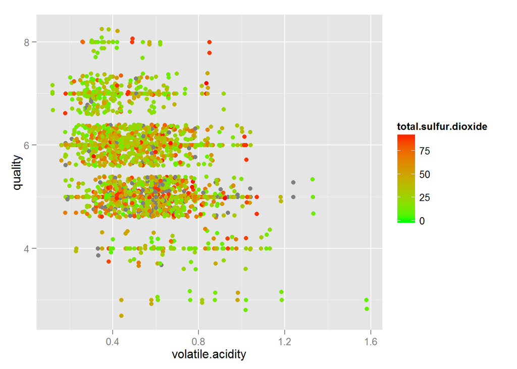

From the above quality VS volatile plots, we can see pretty clearly that when volatile is constant: higher alcohol wine tends to have higher quality; higher sulphates wine tends to have higher quality; higher fixed acidity wine tends to have higher quality; lower density wine tends to have higher quality; higher citric acid wine tends to have higher quality.

I would like to build a linear model and use the other features to predict red wine quality. Since most quality values are 5 or 6, I would like to set the intercept to be 5. I know this set of data may not be very suitable to adapt linear model, but I’m curious what a linear model can tell us.

```
##
## Calls:
## m1: lm(formula = quality ~ 0 + alcohol, data = pf, offset = rep(5,
##     length(quality)))
## m2: lm(formula = quality ~ alcohol + volatile.acidity - 1, data = pf,
##     offset = rep(5, length(quality)))
## m3: lm(formula = quality ~ alcohol + volatile.acidity + sulphates -
##     1, data = pf, offset = rep(5, length(quality)))
## m4: lm(formula = quality ~ alcohol + volatile.acidity + sulphates +
##     citric.acid - 1, data = pf, offset = rep(5, length(quality)))
## m5: lm(formula = quality ~ alcohol + volatile.acidity + sulphates +
##     citric.acid + total.sulfur.dioxide - 1, data = pf, offset = rep(5,
##     length(quality)))
## m6: lm(formula = quality ~ alcohol + volatile.acidity + sulphates +
##     citric.acid + total.sulfur.dioxide + density - 1, data = pf,
##     offset = rep(5, length(quality)))
## m7: lm(formula = quality ~ alcohol + volatile.acidity + sulphates +
##     citric.acid + total.sulfur.dioxide + density + chlorides -
##     1, data = pf, offset = rep(5, length(quality)))
## m8: lm(formula = quality ~ alcohol + volatile.acidity + sulphates +
##     citric.acid + total.sulfur.dioxide + density + chlorides +
##     fixed.acidity - 1, data = pf, offset = rep(5, length(quality)))
## m9: lm(formula = quality ~ alcohol + volatile.acidity + sulphates +
##     citric.acid + total.sulfur.dioxide + density + chlorides +
##     fixed.acidity + pH - 1, data = pf, offset = rep(5, length(quality)))
## m10: lm(formula = quality ~ alcohol + volatile.acidity + sulphates +
##     citric.acid + total.sulfur.dioxide + density + chlorides +
##     fixed.acidity + pH + free.sulfur.dioxide - 1, data = pf,
##     offset = rep(5, length(quality)))
## m11: lm(formula = quality ~ alcohol + volatile.acidity + sulphates +
##     citric.acid + total.sulfur.dioxide + density + chlorides +
##     fixed.acidity + pH + free.sulfur.dioxide + residual.sugar -
##     1, data = pf, offset = rep(5, length(quality)))
## m11: lm(formula = quality ~ alcohol + volatile.acidity + sulphates +
##     citric.acid + total.sulfur.dioxide + density + chlorides +
##     fixed.acidity + pH + free.sulfur.dioxide + residual.sugar -
##     1, data = pf, offset = rep(5, length(quality)))
##
## =============================================================================================================================================
##                          m1        m2        m3        m4        m5        m6        m7        m8        m9        m10       m11       m11
```

[output cut: 20 more lines]

```
##                                                                                                                 (0.002)   (0.002)   (0.002)
## residual.sugar                                                                                                             0.009     0.009
##                                                                                                                           (0.012)   (0.012)
## ---------------------------------------------------------------------------------------------------------------------------------------------
## R-squared                 0.982     0.985     0.985     0.986     0.986     0.987     0.987     0.987     0.987     0.987     0.987     0.987
## adj. R-squared            0.982     0.985     0.985     0.986     0.986     0.987     0.987     0.987     0.987     0.987     0.987     0.987
## sigma                     0.778     0.690     0.689     0.686     0.677     0.655     0.652     0.650     0.649     0.648     0.648     0.648
## F                     84884.785 53972.437 36096.252 27244.092 22373.494 19855.734 17217.807 15131.775 13513.617 12190.967 11079.799 11079.799
## p                         0.000     0.000     0.000     0.000     0.000     0.000     0.000     0.000     0.000     0.000     0.000     0.000
## Log-likelihood        -1867.048 -1673.487 -1670.813 -1665.056 -1643.425 -1589.914 -1580.262 -1576.297 -1572.110 -1569.753 -1569.461 -1569.461
## Deviance                967.317   759.321   756.785   751.355   731.300   683.955   675.747   672.405   668.893   666.923   666.680   666.680
## AIC                    3738.097  3352.975  3349.626  3340.113  3298.851  3193.829  3176.524  3170.594  3164.221  3161.506  3162.922  3162.922
## BIC                    3748.851  3369.106  3371.135  3366.998  3331.114  3231.468  3219.541  3218.989  3217.992  3220.655  3227.448  3227.448
## N                      1599      1599      1599      1599      1599      1599      1599      1599      1599      1599      1599      1599
## =============================================================================================================================================
```

From the statistics, we see that with alcohol and volatile acidity, the R square value is already very close to the maximum. Adding more other feature does not promote the prediction very much.

# Multivariate Analysis

### Talk about some of the relationships you observed in this part of the investigation. Were there features that strengthened each other in terms of looking at your feature(s) of interest?

When holding volatile acidity constant, it’s very clear that higher alcohol wine tends to have higher quality and vice verse.

Other relationships include: when holding volatile acidity constant: higher sulphates wine tends to have higher quality; higher fixed acidity wine tends to have higher quality; lower density wine tends to have higher quality; higher citric acid wine tends to have higher quality; when holding alcohol constant: higher ciric wine tends to have higher quality; lower density wine tends to have higher quality and etc.

### OPTIONAL: Did you create any models with your dataset? Discuss the strengths and limitations of your model.

I used linear model to predict quality. I set the intercept to be a fixed value 5, because the distribution of quality is pretty concentrative. Although the prediction is good, I don’t think this models is 100% suitable to this case, since there are acturally very weak correlation between quality and other features. I’m eager to learn the next course which is machine learning. That course should tell me how to predict the feature of interest better.